# UNICEF Child Labour & Life Expectancy Analysis

## Gender Wise Child Labour:

A bar chart has been constructed to represent the gender-specific child labour threshold and is attached below. Surprisingly, the child labour barrier is higher for females than for males, at 66.58% and 55.27%, respectively. The total child labour threshold is 60.77%, which is quite high.

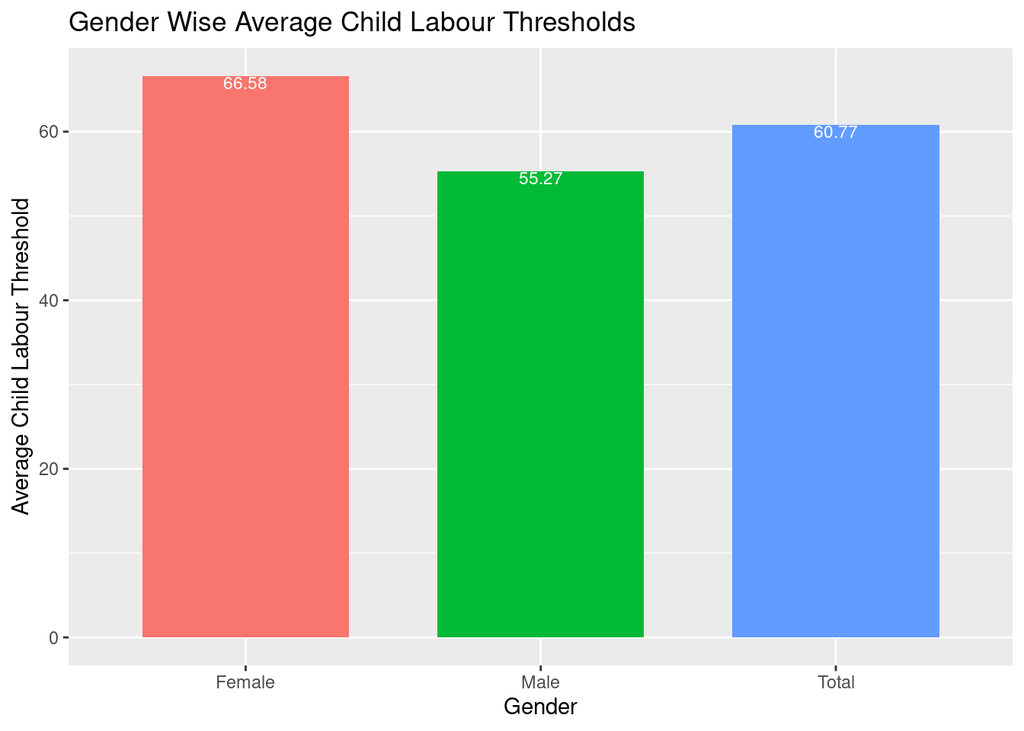

## Relationship Between Military Expense of GDP and Life Expectancy:

A scatter chart is generated to see whether there is a relationship between military expenditure on GDP and life expectancy at birth. A scatter plot with a regression line fitted to it is created and attached below. The regression line is downward, indicating a negative association between the two variables. This suggests that increasing military expenditure of GDP reduces life expectancy at birth, but decreasing military expenditure of GDP increases life expectancy at birth.

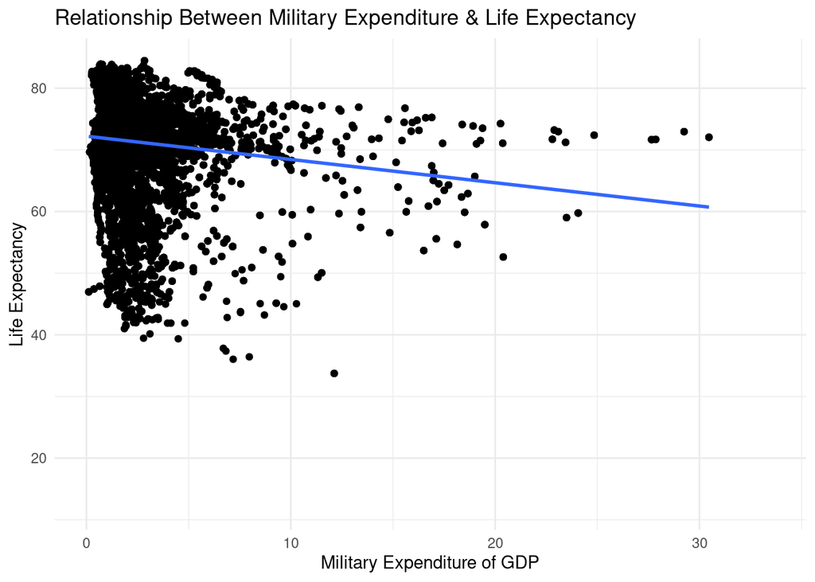

## Trend of Military Expenditure of GDP:

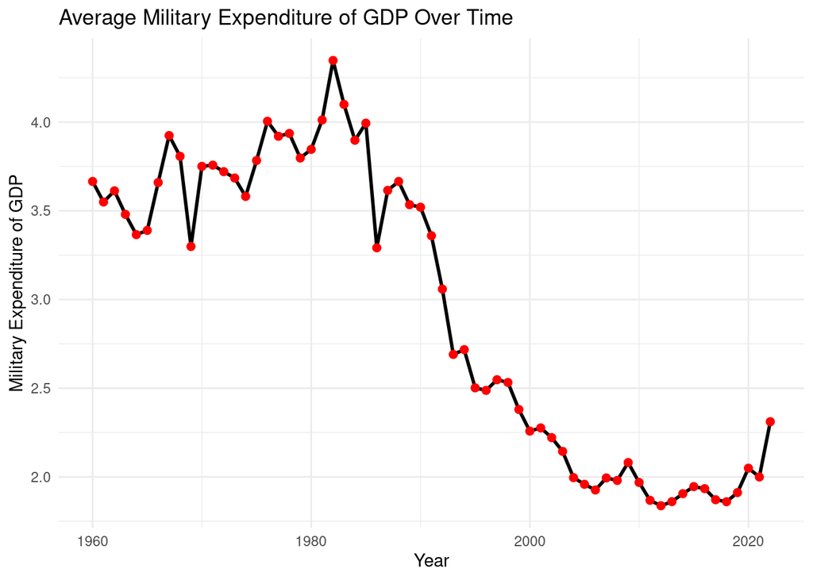

## Military Expenditure of GDP By Country:

Finally, a world map is created which is attached below. The map shows the average military expenditure of GDP by each country. The top 3 countries with highest average military expenditure of GDP are Israel, Saudia Arabia and Qatar.

[interactive chart not shown]